# El Paso Wasterwater Surveillance Time Series Analysis

June 28, 2023

**Change of this version** (7/1/2022)

1. Updated the data until 5/30/2022
2. Changed measure of waste water concentration to “per L”
3. Changed figure labeling

**Analysis Objective**: Process, analyze the time series data from WW Surveillance collected from El Paso, Texas

1. Process the data from multiple excel sheets to a combined dataset (long format)
2. Exploratory analysis of time series figures with WW concentration
3. Exploratory analysis of time series figures with COVID reported case data
4. Cross-correlation between the case and WW concentration - see this link for reading https://online.stat.psu.edu/stat510/lesson/8/8.2

# Data processing

Read in raw data and export an organized dataset. Time framework is between 6/22/2020 and 6/1/2022.

| WWTP Site | Date Collected | Sample ID | Sample Name | N1 Cт | Quantity for 10 ul volume into PCR (N1) | Copies per L waste water (N1) | N2 CT | Quantity for 10 ul volume into PCR (N2) | Copies per L waste water (N2) | AVG Flowrate (MGD) |
| --- | --- | --- | --- | --- | --- | --- | --- | --- | --- | --- |
| John T. Hickerson | 2020-10-07 | JT 20-33988 | JT 10/07/20 | 31.248 | NA | NA | 35.586 | NA | NA | NA |
| Roberto Bustamante | 2021-07-28 | RB 21-22149 | RB 7/28/21 | 32.600 | 219.2 | 146133.33 | 35.700 | 33.6 | 22400.000 | 26.52 |
| Fred Hurvey | 2021-05-12 | FH 21-13346 | FH 5/12/21 | 34.000 | 82.2 | 54800.00 | 36.800 | 14.9 | 9933.333 | 5.71 |
| Haskell | 2020-06-29 | HS 20-22427 | HS 06/29/20 | NA | NA | NA | NA | NA | NA | NA |
| John T. Hickerson | 2022-01-13 | JT 22-01309 | JT 01/13/22 | 29.200 | 2751.5 | 1834333.33 | 30.000 | 1983.9 | 1322600.000 | 7.07 |
| Roberto Bustamante | 2021-06-25 | RB 21-18170 | RB 6/25/21 | 35.900 | 18.8 | 12533.33 | 37.100 | 12.0 | 8000.000 | 26.52 |
| John T. Hickerson | 2021-03-17 | NA | JT 03/17/21 | 32.800 | 187.2 | 124800.00 | 35.700 | 33.3 | 22200.000 | 7.89 |
| Roberto Bustamante | 2021-09-22 | RB 21-28406 | RB 9/22/21 | 32.700 | 215.2 | 143466.67 | 34.300 | 90.5 | 60333.333 | 26.52 |
| John T. Hickerson | 2021-01-21 | NA | JT 01/21/21 | 30.600 | 976.3 | 650866.67 | 32.000 | 480.6 | 320400.000 | 7.89 |
| John T. Hickerson | 2021-12-01 | JT 21-35103 | JT 12/1/21 | 34.600 | 52.0 | 34666.67 | 38.900 | 3.3 | 2200.000 | 7.07 |

- Sample extraction volume: 300ul; RNA elution: 100ul; PCR input volume: 10ul
- Conversion: $50 ml$ –> $1 ml$ then $300 ul$ –> $100 ul$, so the conversion factor is 150.
- copies per L waste is calculated from quantities for $10 ul$ volume into PCR (PCR input volume): $((copies/10 ul RT-PCR)*100,000)/150$
- Copies per MGD is calculated using copies per L waste water and average flow rate
- What does Ct mean? In a real time PCR assay a positive reaction is detected by accumulation of a fluorescent signal. The Ct (cycle threshold) is defined as the number of cycles required for the fluorescent signal to cross the threshold (ie exceeds background level). **Ct levels are inversely proportional to the amount of target nucleic acid in the sample (ie the lower the Ct level the greater the amount of target nucleic acid in the sample)**
  - Cts < 29 are strong positive reactions indicative of abundant target nucleic acid in the sample
  - Cts of 30-37 are positive reactions indicative of moderate amounts of target nucleic acid
  - Cts of 38-40 are weak reactions indicative of minimal amounts of target nucleic acid which could represent an infection state or environmental contamination.

# Explorary analysis with the the WW concentration (Copies per liter waste water)

For the figures below I modified the following 1) legends shortened to “N1” and “N2” and 2) no need to plot all dates - I modified to print every 4 weeks in the label.

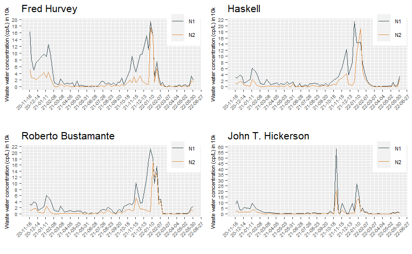

# Time series analysis with the reported number of cases

| ncase | Date | rate | WWTP |
| --- | --- | --- | --- |
| 1 | 2022-05-03 | 1.01 | Fred Hurvey |
| 43 | 2021-02-17 | 43.54 | Fred Hurvey |
| 97 | 2022-03-19 | 24.26 | Roberto Bustamante |
| 21 | 2020-12-26 | 16.41 | John T. Hickerson |
| 35 | 2021-03-23 | 27.90 | Haskell |
| 14 | 2021-09-20 | 10.94 | John T. Hickerson |
| 37 | 2022-02-19 | 28.91 | John T. Hickerson |
| 22 | 2021-03-16 | 22.28 | Fred Hurvey |
| 17 | 2021-04-23 | 17.21 | Fred Hurvey |
| 35 | 2022-05-27 | 27.90 | Haskell |

For the figures, can we over lay the WW time series and the case data (perhaps case data y-axis on the right), to see how the trends correlate? Looks like we need to do this for each facility (i.e., Fred Hurvey, Haskell etc)

## COVID-19 infection rate (per 100k population) by four waste water treatment facilities

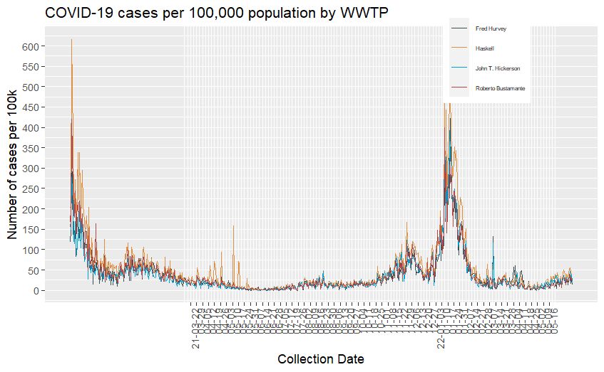

## Overlay cases with WW time series plot

### Fred Hurvey

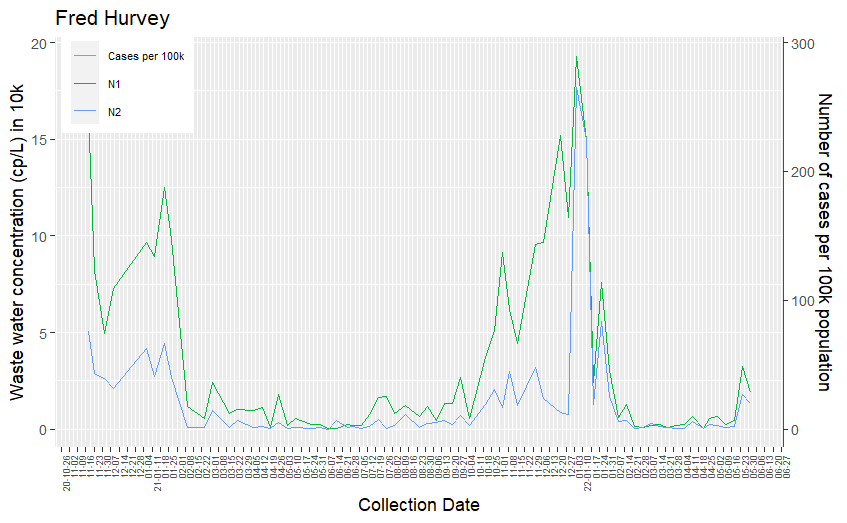

### Haskell

[output not shown]

# Cross-correlation analysis between reported cases and WW concentration

Cross-correlation may help us identify the leading time when virus in WW started to show a pikes before the cases were increasing.

1. When $h < 0$ , $x$ leads $y$.
2. When $h > 0$ , $x$ lags $y$.